# 🦇 Neural Networks

## Network 2: One Data Point

Algebraic form

Take the first row: $x_1 = 1$, $x_2 = 0$, $y = 1$. Blue: the sum going **into** the activation. Red: the value coming **out** of it.

**Hidden layer, before the activation**
$$\begin{gathered}\textcolor{#1f4fd8}{z_{h_1} = 6 + (-4)(1) + (0)(0) = 2} \\ \textcolor{#1f4fd8}{z_{h_2} = -14 + (4)(1) + (0)(0) = -10}\end{gathered}$$

**Hidden layer, after the sigmoid**
$$\begin{gathered}\textcolor{#b5302a}{h_1 = \frac{1}{1 + e^{-2}} = 0.881} \\ \textcolor{#b5302a}{h_2 = \frac{1}{1 + e^{-(-10)}} = 0.000}\end{gathered}$$

**Output layer, before the activation**
$$\begin{gathered}\textcolor{#1f4fd8}{z_{\hat{y}} = -2 + (4)(0.881) + (4)(0.000) = 1.524}\end{gathered}$$

**Output layer, after the sigmoid**
$$\begin{gathered}\textcolor{#b5302a}{\hat{y} = \frac{1}{1 + e^{-1.524}} = 0.821}\end{gathered}$$

$\hat{y} = 0.821 > 0.5$, so the network predicts class 1, which is correct.

Network form

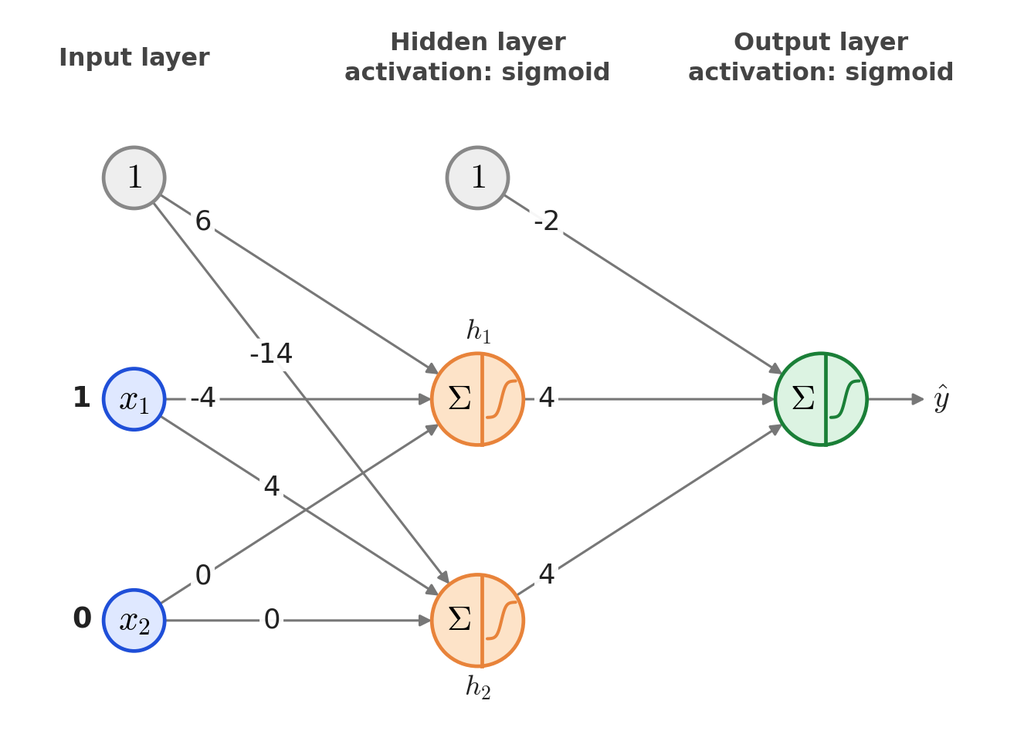

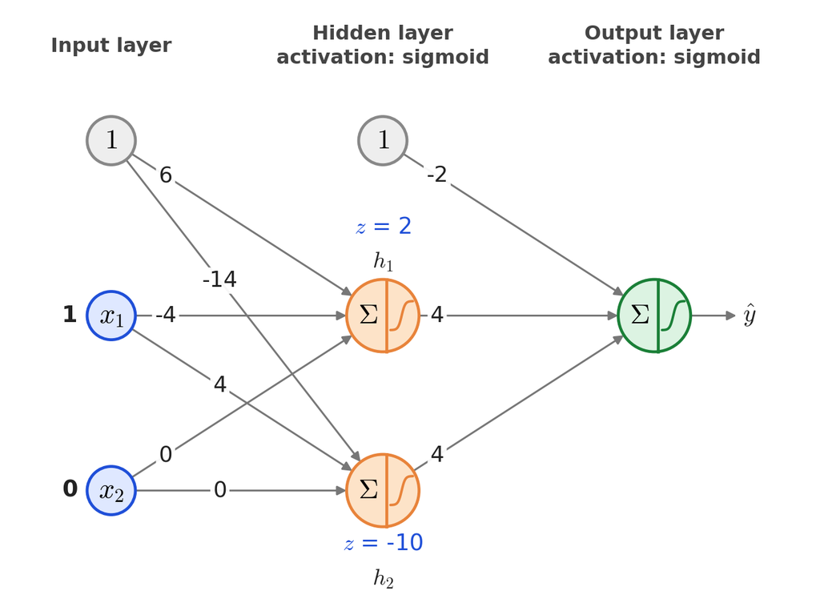

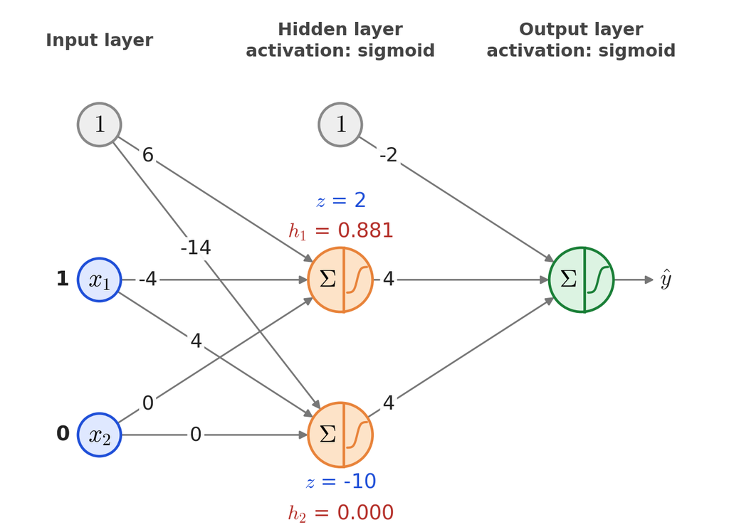

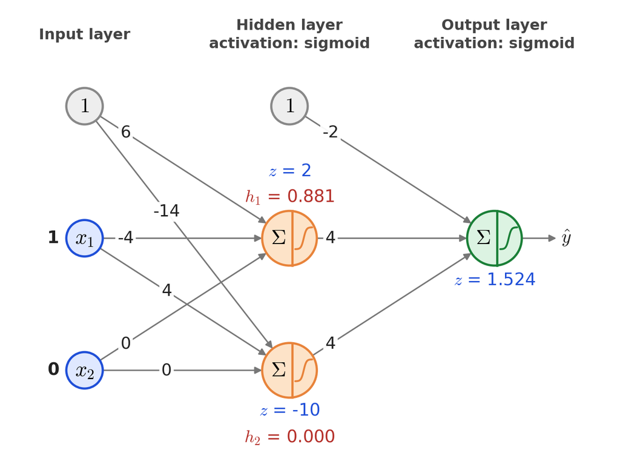

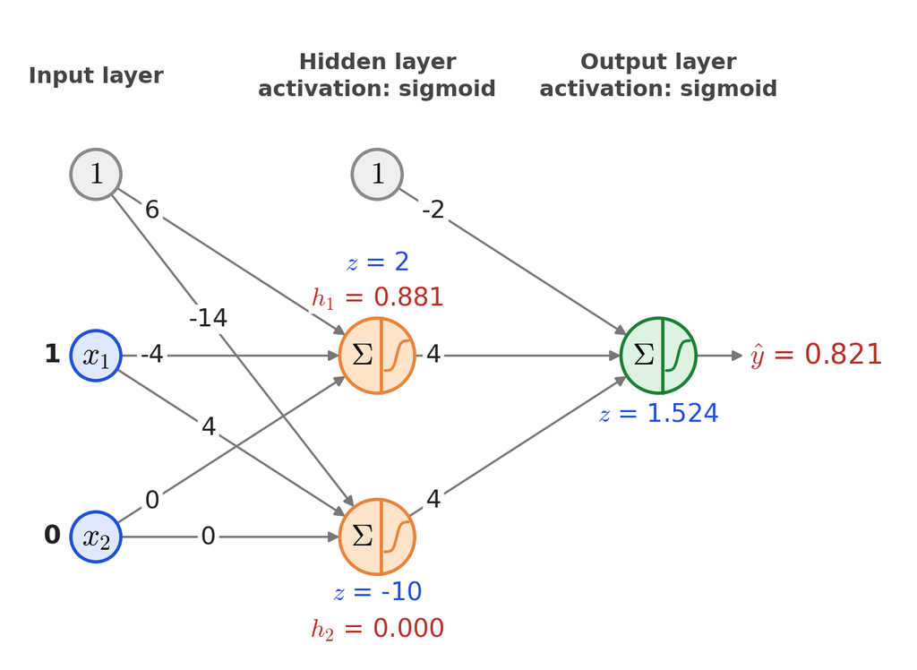

## Network 2 vs. Logistic Regression

Logistic regression (trained)

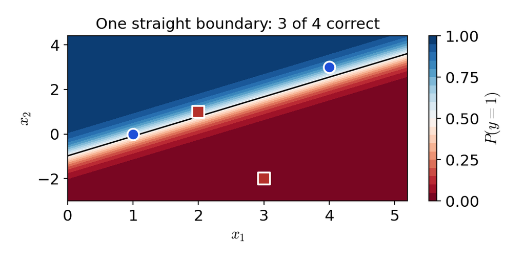

Network 2 (weights picked by hand)

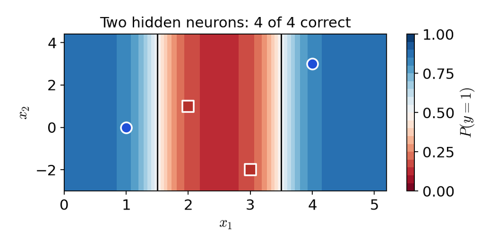

| $x_1$ | $x_2$ | $y$ | $h_1$ | $h_2$ | $\hat{y}$ | Predicted class |
| --- | --- | --- | --- | --- | --- | --- |
| 1 | 0 | 1 | 0.881 | 0.000 | 0.821 | 1 |
| 2 | 1 | 0 | 0.119 | 0.002 | 0.180 | 0 |
| 3 | -2 | 0 | 0.002 | 0.119 | 0.180 | 0 |
| 4 | 3 | 1 | 0.000 | 0.881 | 0.821 | 1 |

## Network 3: Two Hidden Layers

Algebraic form

Hidden layer 1:

$$h_1 = \frac{1}{1 + e^{-(w_{10} + w_{11} x_1 + w_{12} x_2)}}$$

$$h_2 = \frac{1}{1 + e^{-(w_{20} + w_{21} x_1 + w_{22} x_2)}}$$

Hidden layer 2:

$$g_1 = \frac{1}{1 + e^{-(u_{10} + u_{11} h_1 + u_{12} h_2)}}$$

$$g_2 = \frac{1}{1 + e^{-(u_{20} + u_{21} h_1 + u_{22} h_2)}}$$

Output layer:

$$\hat{y} = v_0 + v_1 g_1 + v_2 g_2$$

**Activations:** sigmoid in both hidden layers, linear in the output layer.

This network has **15** parameters.

Network form

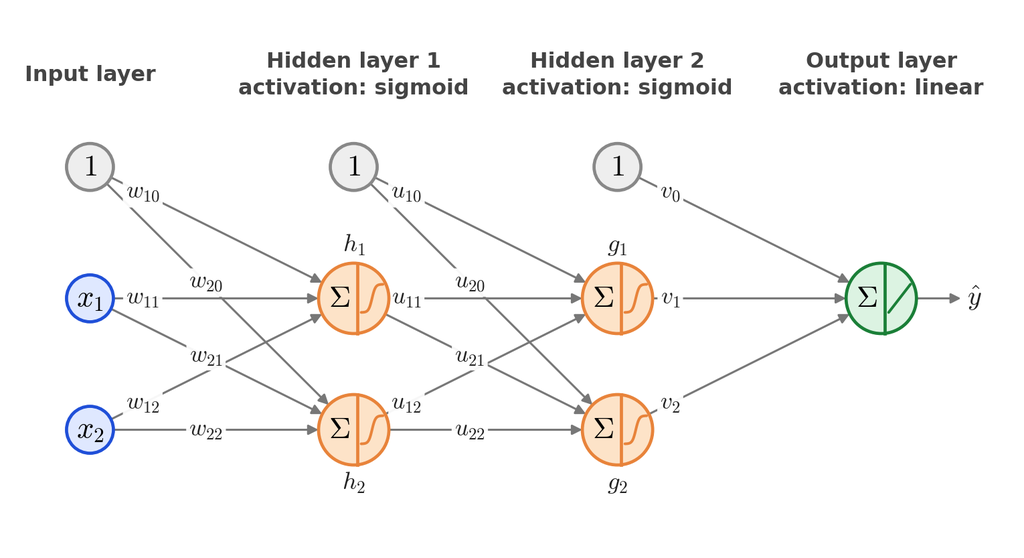

## Network 3: One Data Point

Algebraic form

Input: $x_1 = 2$, $x_2 = 1$, with true value $y = 0$. Blue: the sum going **into** the activation. Red: the value coming **out** of it.

**Hidden layer 1, before and after the sigmoid**
$$\begin{gathered}\textcolor{#1f4fd8}{z_{h_1} = -1 + (0.5)(2) + (0.5)(1) = 0.5} \\ \textcolor{#1f4fd8}{z_{h_2} = 1 + (-1)(2) + (0.5)(1) = -0.5}\end{gathered}$$
$$\begin{gathered}\textcolor{#b5302a}{h_1 = \frac{1}{1 + e^{-0.5}} = 0.622} \\ \textcolor{#b5302a}{h_2 = \frac{1}{1 + e^{-(-0.5)}} = 0.378}\end{gathered}$$

**Hidden layer 2, before and after the sigmoid**
$$\begin{gathered}\textcolor{#1f4fd8}{z_{g_1} = -1 + (2)(0.622) + (-1)(0.378) = -0.134} \\ \textcolor{#1f4fd8}{z_{g_2} = 0.5 + (-1)(0.622) + (1)(0.378) = 0.256}\end{gathered}$$
$$\begin{gathered}\textcolor{#b5302a}{g_1 = \frac{1}{1 + e^{-(-0.134)}} = 0.467} \\ \textcolor{#b5302a}{g_2 = \frac{1}{1 + e^{-0.256}} = 0.564}\end{gathered}$$

**Output layer, before and after the linear activation**
$$\begin{gathered}\textcolor{#1f4fd8}{z_{\hat{y}} = -1 + (1)(0.467) + (2)(0.564) = 0.595}\end{gathered}$$
$$\begin{gathered}\textcolor{#b5302a}{\hat{y} = z_{\hat{y}} = 0.595}\end{gathered}$$

Network form

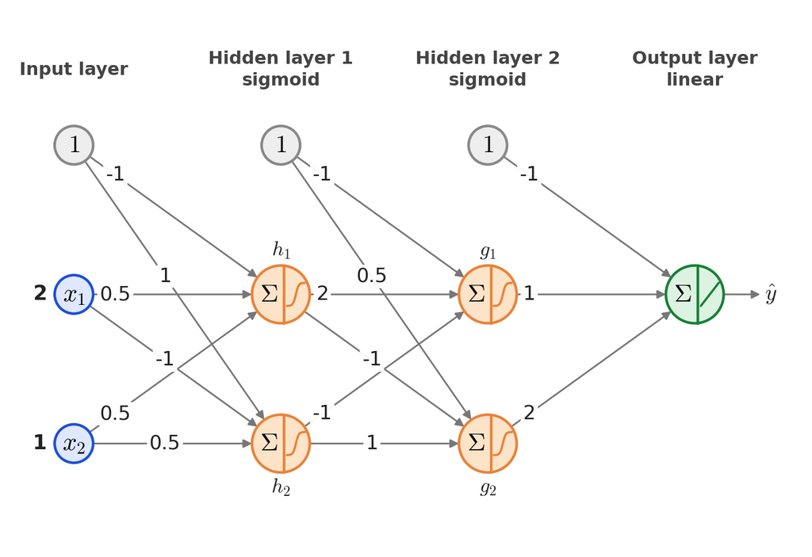

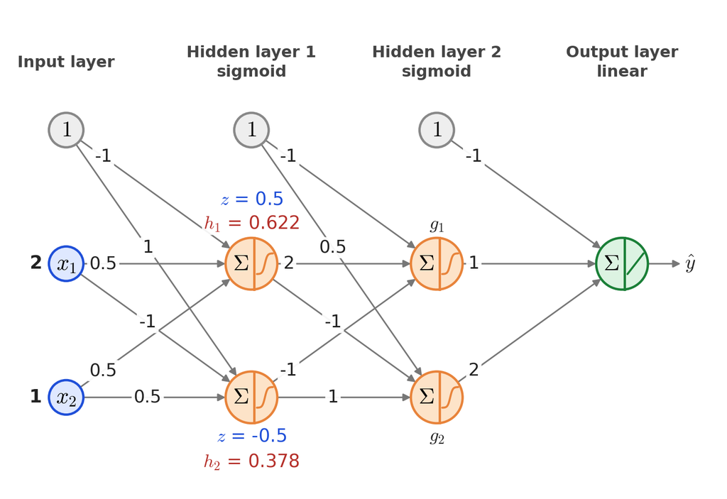

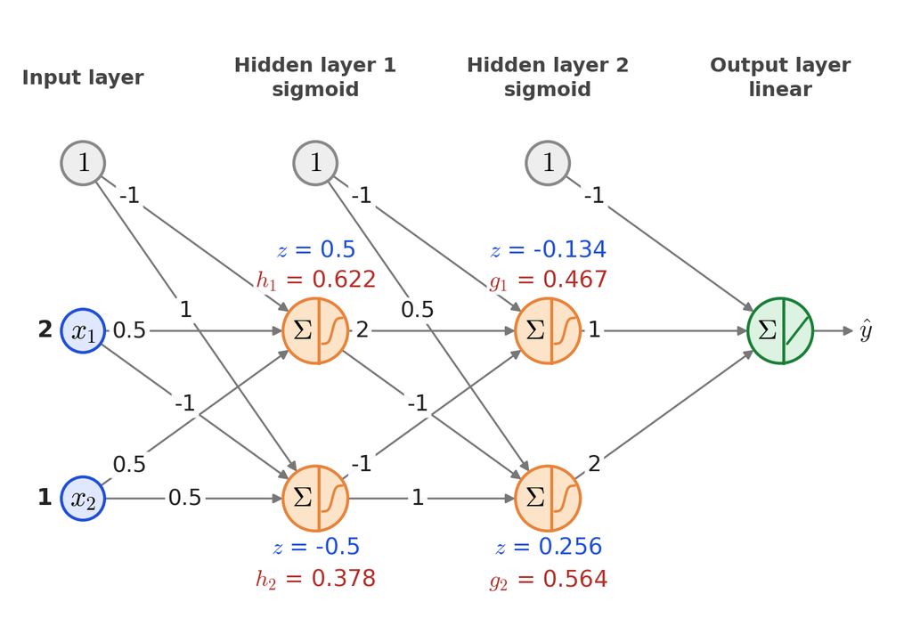

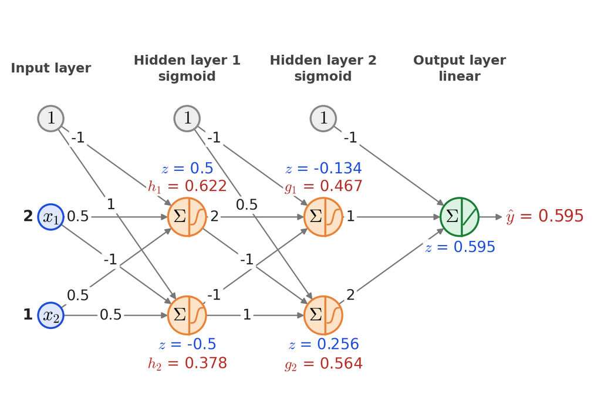

## A Simple Picture, a Long Formula: Network 2

Network form

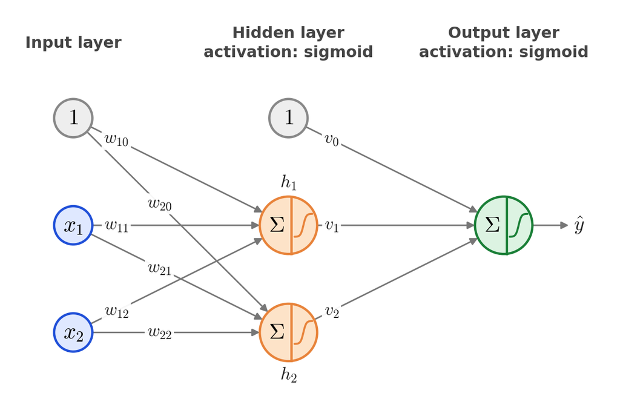

Algebraic form

Layer by layer:

$$h_1 = \frac{1}{1 + e^{-(w_{10} + w_{11} x_1 + w_{12} x_2)}}$$

$$h_2 = \frac{1}{1 + e^{-(w_{20} + w_{21} x_1 + w_{22} x_2)}}$$

$$\hat{y} = \frac{1}{1 + e^{-(v_0 + v_1 h_1 + v_2 h_2)}}$$

The same thing, as one formula in $x_1$ and $x_2$:

$$\hat{y} = \cfrac{1}{1 + \exp\left(-\left(v_0 + \cfrac{v_1}{1 + e^{-(w_{10} + w_{11} x_1 + w_{12} x_2)}} + \cfrac{v_2}{1 + e^{-(w_{20} + w_{21} x_1 + w_{22} x_2)}}\right)\right)}$$

## A Simple Picture, a Long Formula: Network 3

Network form

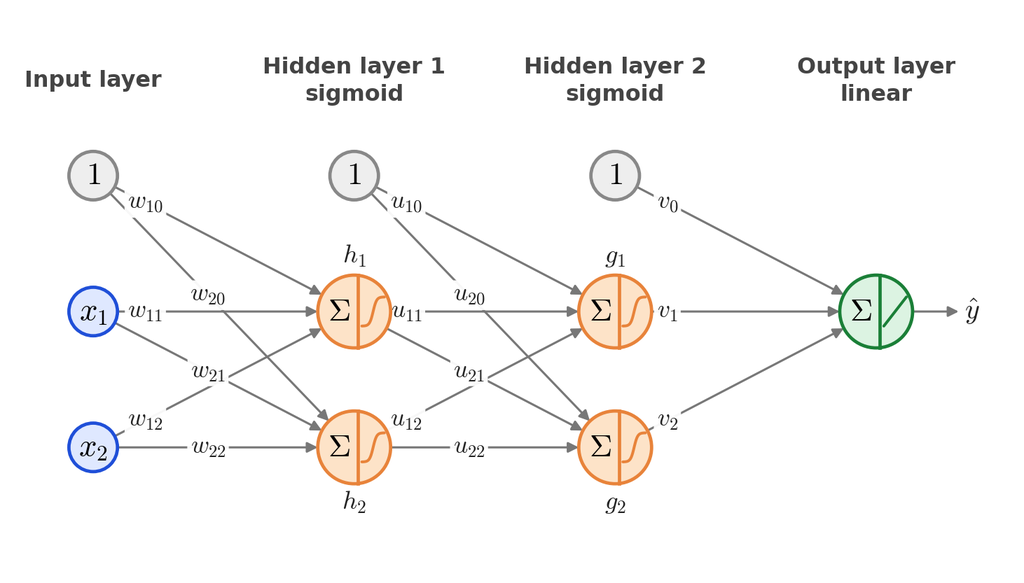

The picture has one node each for $h_1$ and $h_2$. The formula has to write each of them out **twice**, because both $g_1$ and $g_2$ use them.

Algebraic form, as one formula

$$\begin{aligned}\hat{y} = {} & v_0 \\[10pt] & + \dfrac{v_{1}}{1 + \exp\left(-\left(u_{10} + \dfrac{u_{11}}{1 + e^{-(w_{10} + w_{11} x_1 + w_{12} x_2)}} + \dfrac{u_{12}}{1 + e^{-(w_{20} + w_{21} x_1 + w_{22} x_2)}}\right)\right)} \\[10pt] & + \dfrac{v_{2}}{1 + \exp\left(-\left(u_{20} + \dfrac{u_{21}}{1 + e^{-(w_{10} + w_{11} x_1 + w_{12} x_2)}} + \dfrac{u_{22}}{1 + e^{-(w_{20} + w_{21} x_1 + w_{22} x_2)}}\right)\right)}\end{aligned}$$

## A Simple Picture: Network 4

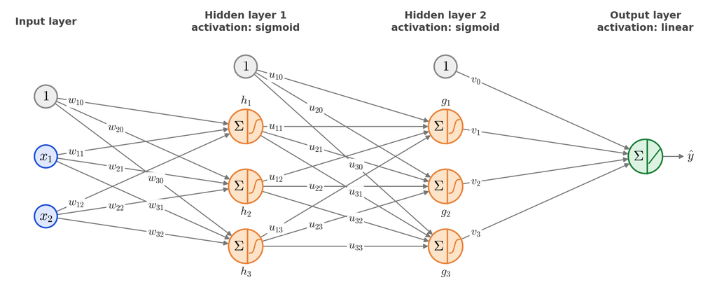

Network 3 with one more node in each hidden layer: **25** parameters.

## A Long Formula: Network 4

Layer by layer:

$$h_i = \frac{1}{1 + e^{-(w_{i0} + w_{i1} x_1 + w_{i2} x_2)}}$$

$$g_j = \frac{1}{1 + e^{-(u_{j0} + u_{j1} h_1 + u_{j2} h_2 + u_{j3} h_3)}}$$

$$\hat{y} = v_0 + v_1 g_1 + v_2 g_2 + v_3 g_3$$

Here $i$ and $j$ each take the values 1, 2 and 3. The same network, as one formula in $x_1$ and $x_2$:

$$\begin{aligned}\hat{y} = {} & v_0 \\[10pt] & + \dfrac{v_{1}}{1 + \exp\left(-\left(u_{10} + \dfrac{u_{11}}{1 + e^{-(w_{10} + w_{11} x_1 + w_{12} x_2)}} + \dfrac{u_{12}}{1 + e^{-(w_{20} + w_{21} x_1 + w_{22} x_2)}} + \dfrac{u_{13}}{1 + e^{-(w_{30} + w_{31} x_1 + w_{32} x_2)}}\right)\right)} \\[10pt] & + \dfrac{v_{2}}{1 + \exp\left(-\left(u_{20} + \dfrac{u_{21}}{1 + e^{-(w_{10} + w_{11} x_1 + w_{12} x_2)}} + \dfrac{u_{22}}{1 + e^{-(w_{20} + w_{21} x_1 + w_{22} x_2)}} + \dfrac{u_{23}}{1 + e^{-(w_{30} + w_{31} x_1 + w_{32} x_2)}}\right)\right)} \\[10pt] & + \dfrac{v_{3}}{1 + \exp\left(-\left(u_{30} + \dfrac{u_{31}}{1 + e^{-(w_{10} + w_{11} x_1 + w_{12} x_2)}} + \dfrac{u_{32}}{1 + e^{-(w_{20} + w_{21} x_1 + w_{22} x_2)}} + \dfrac{u_{33}}{1 + e^{-(w_{30} + w_{31} x_1 + w_{32} x_2)}}\right)\right)}\end{aligned}$$

## A Simple Picture: Network 5

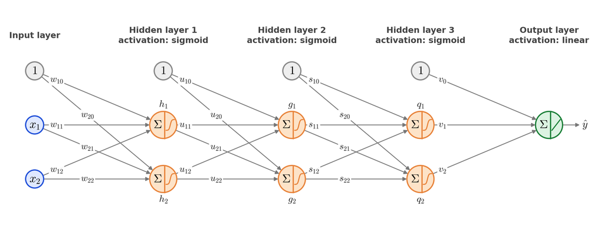

Three hidden layers of two nodes: **21** parameters, and every layer has the same simple pattern.

## A Long Formula: Network 5

Layer by layer, where $i$ and $j$ each take the values 1 and 2:

$$h_i = \frac{1}{1 + e^{-(w_{i0} + w_{i1} x_1 + w_{i2} x_2)}}$$

$$g_j = \frac{1}{1 + e^{-(u_{j0} + u_{j1} h_1 + u_{j2} h_2)}}$$

$$q_j = \frac{1}{1 + e^{-(s_{j0} + s_{j1} g_1 + s_{j2} g_2)}}$$

$$\hat{y} = v_0 + v_1 q_1 + v_2 q_2$$

The same network, as one formula in $x_1$ and $x_2$:

$$\begin{aligned}\hat{y} = {} & v_0 \\[14pt] & + \dfrac{v_{1}}{1 + \exp\left(-\left(s_{10} + \dfrac{s_{11}}{1 + \exp\left(-\left(u_{10} + \dfrac{u_{11}}{1 + e^{-(w_{10} + w_{11} x_1 + w_{12} x_2)}} + \dfrac{u_{12}}{1 + e^{-(w_{20} + w_{21} x_1 + w_{22} x_2)}}\right)\right)} + \dfrac{s_{12}}{1 + \exp\left(-\left(u_{20} + \dfrac{u_{21}}{1 + e^{-(w_{10} + w_{11} x_1 + w_{12} x_2)}} + \dfrac{u_{22}}{1 + e^{-(w_{20} + w_{21} x_1 + w_{22} x_2)}}\right)\right)}\right)\right)} \\[14pt] & + \dfrac{v_{2}}{1 + \exp\left(-\left(s_{20} + \dfrac{s_{21}}{1 + \exp\left(-\left(u_{10} + \dfrac{u_{11}}{1 + e^{-(w_{10} + w_{11} x_1 + w_{12} x_2)}} + \dfrac{u_{12}}{1 + e^{-(w_{20} + w_{21} x_1 + w_{22} x_2)}}\right)\right)} + \dfrac{s_{22}}{1 + \exp\left(-\left(u_{20} + \dfrac{u_{21}}{1 + e^{-(w_{10} + w_{11} x_1 + w_{12} x_2)}} + \dfrac{u_{22}}{1 + e^{-(w_{20} + w_{21} x_1 + w_{22} x_2)}}\right)\right)}\right)\right)}\end{aligned}$$

## The Picture Grows Slowly. The Formula Does Not.

| Network | Parameters (numbers in the picture) | Times the sigmoid appears in the single formula | Times $x_1$ appears in the single formula |
| --- | --- | --- | --- |
| Network 2 | 9 | 3 | 2 |
| Network 3 | 15 | 6 | 4 |
| Network 4 | 25 | 12 | 9 |
| Network 5 | 21 | 14 | 8 |
| Two hidden layers of 10 | 151 | 110 | 100 |
| Three hidden layers of 100 | 20,601 | 1,010,100 | 1,000,000 |
| Ten hidden layers of 100 | 91,301 | about $10^{20}$ | $10^{20}$ |

- The picture needs each node drawn once, and each node reuses the layer before it. The written-out formula repeats that work every time a node is used.
- Ten hidden layers of 100 nodes have about 91,000 parameters, yet the written-out formula would mention $x_1$ $10^{20}$ times.

A simple graph can stand for a function we could never write down in full, and the computer never has to: it works through the graph one layer at a time, exactly as in our worked examples.

## What These Functions Look Like

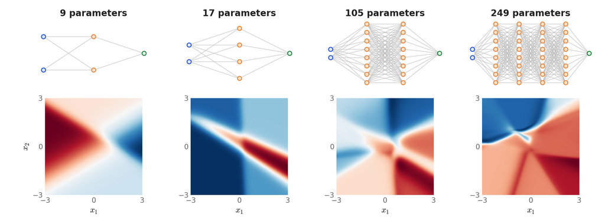

- Each panel colors every $(x_1, x_2)$ by the network’s $\hat{y}$: red is low and blue is high, on each panel’s own scale. Hidden layers use the sigmoid, and the output is linear. Bias nodes are not drawn, but they are counted.
- The weights are **random**, not trained, and these four were picked from a few random draws. They only show the kinds of shapes these graphs can produce.

## Why Do Hidden Layers Need a Nonlinear Activation?

Linear activation in the hidden layer

$$h_1 = w_{10} + w_{11} x_1 + w_{12} x_2$$

$$h_2 = w_{20} + w_{21} x_1 + w_{22} x_2$$

$$\hat{y} = v_0 + v_1 h_1 + v_2 h_2$$

Substitute $h_1$ and $h_2$ and collect terms:

$$\begin{aligned}\hat{y} = {} & (v_0 + v_1 w_{10} + v_2 w_{20}) \\ & + (v_1 w_{11} + v_2 w_{21}) x_1 \\ & + (v_1 w_{12} + v_2 w_{22}) x_2\end{aligned}$$

This still has the form $\hat{y} = w_0 + w_1 x_1 + w_2 x_2$. **It is a linear model again**, as we saw in Part 1.

Sigmoid activation in the hidden layer

$$h_1 = \frac{1}{1 + e^{-(w_{10} + w_{11} x_1 + w_{12} x_2)}}$$

$$h_2 = \frac{1}{1 + e^{-(w_{20} + w_{21} x_1 + w_{22} x_2)}}$$

$$\hat{y} = v_0 + v_1 h_1 + v_2 h_2$$

Substitute $h_1$ and $h_2$:

$$\hat{y} = v_0 + \frac{v_1}{1 + e^{-(w_{10} + w_{11} x_1 + w_{12} x_2)}} + \frac{v_2}{1 + e^{-(w_{20} + w_{21} x_1 + w_{22} x_2)}}$$

The terms cannot be collected. **The model is no longer linear in $x_1$ and $x_2$**, which is why Network 2 could classify all four points.

## Counting Parameters from the Architecture

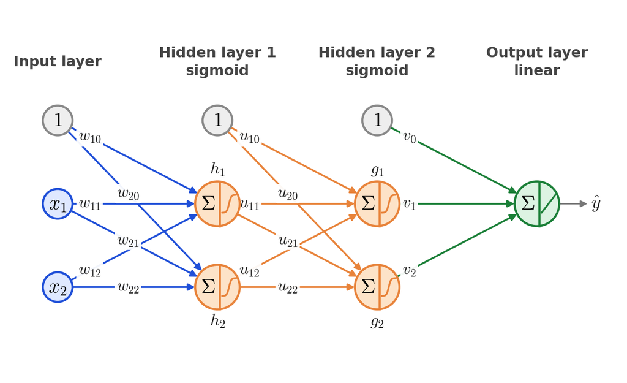

**Every arrow is one parameter**, so we count arrows one layer at a time. Take Network 3, with layer sizes 2, 2, 2, 1.

| Arrows into | Arrows per node | Nodes | Parameters |
| --- | --- | --- | --- |
| ■ Hidden layer 1 | 2 inputs + 1 bias = 3 | 2 | $3 \times 2 = 6$ |
| ■ Hidden layer 2 | 2 nodes + 1 bias = 3 | 2 | $3 \times 2 = 6$ |
| ■ Output layer | 2 nodes + 1 bias = 3 | 1 | $3 \times 1 = 3$ |
| **Total** |  |  | $\mathbf{15}$ |

For example, node $h_1$ has 3 parameters: $w_{10}$, $w_{11}$ and $w_{12}$.

**The rule:** if a layer has $k$ nodes and the layer before it has $m$ nodes, not counting its bias node, then that layer has $(m + 1) \times k$ parameters. Add this up over every layer after the input layer.

The input layer has no parameters: its values come from the data. Activation functions add none either: changing sigmoid to ReLU leaves the count the same.

## Counting Parameters: More Examples

| Network | Layer sizes | Parameters by layer | Total |
| --- | --- | --- | --- |
| Linear model | 2, 1 | $(2 + 1) \times 1$ | $\mathbf{3}$ |
| Network 4 | 2, 3, 3, 1 | $(2 + 1) \times 3 + (3 + 1) \times 3 + (3 + 1) \times 1$ | $9 + 12 + 4 = \mathbf{25}$ |
| Network 5 | 2, 2, 2, 2, 1 | $(2 + 1) \times 2 + (2 + 1) \times 2 + (2 + 1) \times 2 + (2 + 1) \times 1$ | $6 + 6 + 6 + 3 = \mathbf{21}$ |
| Digit images | 784, 128, 10 | $(784 + 1) \times 128 + (128 + 1) \times 10$ | $100{,}480 + 1{,}290 = \mathbf{101{,}770}$ |

- Network 4 has more parameters than Network 5, even though Network 5 has more layers. Parameters depend on the layer sizes as well as the number of layers.
- The size of the **previous** layer sets $m$, so wide layers are expensive. Digit images of 28 × 28 pixels give 784 inputs, and with 128 hidden nodes that first layer alone needs more than 100,000 parameters.

## Counting Parameters: Your Turn

**Your turn:** a network has layer sizes 4, 5, 3, 1. How many parameters does it have?

| Layer | Calculation | Parameters |
| --- | --- | --- |
| Hidden layer 1 | $(4 + 1) \times 5$ | 25 |
| Hidden layer 2 | $(5 + 1) \times 3$ | 18 |
| Output layer | $(3 + 1) \times 1$ | 4 |
| **Total** |  | **47** |

## Summary: Number of Parameters

| Model | Layer sizes | Hidden activation | Output activation | Parameters by layer | Total |
| --- | --- | --- | --- | --- | --- |
| Linear model | 2, 1 | none | linear | 3 | **3** |
| Logistic regression | 2, 1 | none | sigmoid | 3 | **3** |
| Linear, 1 hidden layer | 2, 2, 1 | linear | linear | 6 + 3 | **9** |
| Linear, 2 hidden layers | 2, 2, 2, 1 | linear | linear | 6 + 6 + 3 | **15** |
| Network 1 | 2, 1, 1 | sigmoid | linear | 3 + 2 | **5** |
| Network 2 | 2, 2, 1 | sigmoid | sigmoid | 6 + 3 | **9** |
| Network 3 | 2, 2, 2, 1 | sigmoid | linear | 6 + 6 + 3 | **15** |
| Network 4 | 2, 3, 3, 1 | sigmoid | linear | 9 + 12 + 4 | **25** |
| Network 5 | 2, 2, 2, 2, 1 | sigmoid | linear | 6 + 6 + 6 + 3 | **21** |

**Reminder:** a layer of $k$ nodes after a layer of $m$ nodes has $(m + 1) \times k$ parameters. For Network 2: $(2 + 1) \times 2 = 6$, then $(2 + 1) \times 1 = 3$, so $9$ in total.

- Parameter count alone does not tell you how flexible a network is. “Linear, 1 hidden layer” and Network 2 both have 9, but only Network 2 is nonlinear.
- The output activation follows the task: linear for regression, sigmoid for two-class classification.

## Activation Functions in Well-Known Networks

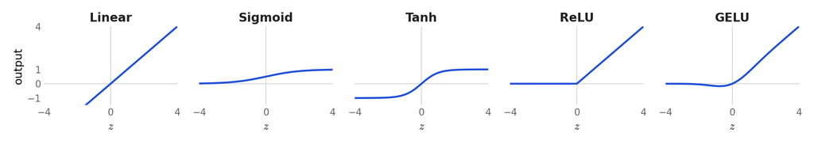

| Activation | Output for input $z$ | Typical use |
| --- | --- | --- |
| Linear | $z$ | Output layer for regression |
| Sigmoid | $1 / (1 + e^{-z})$ | Output layer for two classes |
| Tanh | $(e^{z} - e^{-z}) / (e^{z} + e^{-z})$ | Hidden layers in early networks |
| ReLU | $\max(0, z)$ | Hidden layers in image networks |
| GELU | $z\,\Phi(z)$ | Hidden layers in language models |
| Softmax | $\hat{y}_k = e^{z_k} / \sum_j e^{z_j}$ | Output layer for many classes |

$\Phi$ is the standard normal CDF. Softmax acts on a whole layer at once, so it is not plotted.

## Well-Known Neural Networks

| Network | Year | Task | Parameters | Hidden activation | Output activation |
| --- | --- | --- | --- | --- | --- |
| LeNet-5 | 1998 | Reading handwritten digits | about 60,000 | scaled tanh | radial basis function units |
| AlexNet | 2012 | Image classification | 61.1 million | ReLU | softmax |
| VGG-16 | 2014 | Image classification | 138.4 million | ReLU | softmax |
| ResNet-50 | 2015 | Image classification | 25.6 million | ReLU | softmax |
| BERT (base) | 2018 | Language understanding | 109.5 million | GELU | depends on the task |
| GPT-2 (largest) | 2019 | Text generation | 1.5 billion | GELU | softmax |
| GPT-3 (largest) | 2020 | Text generation | 175 billion | not stated in its paper | softmax |

Network 3 has 15 parameters. GPT-3 has 175 billion. The idea is the same: inputs pass through layers of weights and activation functions to an output.

- These networks are not fully connected throughout. Convolutional and attention layers reuse weights, so the $(m + 1) \times k$ rule applies only to their fully connected layers.
- Counts for AlexNet, VGG-16 and ResNet-50 are for the standard torchvision versions with 1,000 output classes. The AlexNet paper reports about 60 million.

## Back to the Framework

- **Step 1:** Assume the model function $\hat{y} = f(x, w)$. This is what changed today: $f$ is now a network, and $w$ holds all of its parameters.
- **Step 2:** Define the loss function $l(\hat{y}, y)$. Same losses as before:

$$l(\hat{y}, y) = (\hat{y} - y)^2 \quad \text{(regression)} \qquad l(\hat{y}, y) = -y \log(\hat{y}) - (1 - y) \log(1 - \hat{y}) \quad \text{(classification)}$$

- **Step 3:** Find $w$ that minimizes the total loss using gradient descent.

The weights in today’s worked examples were picked by hand. **Next:** how gradient descent finds them by itself.

## Problem: Calculate the Output

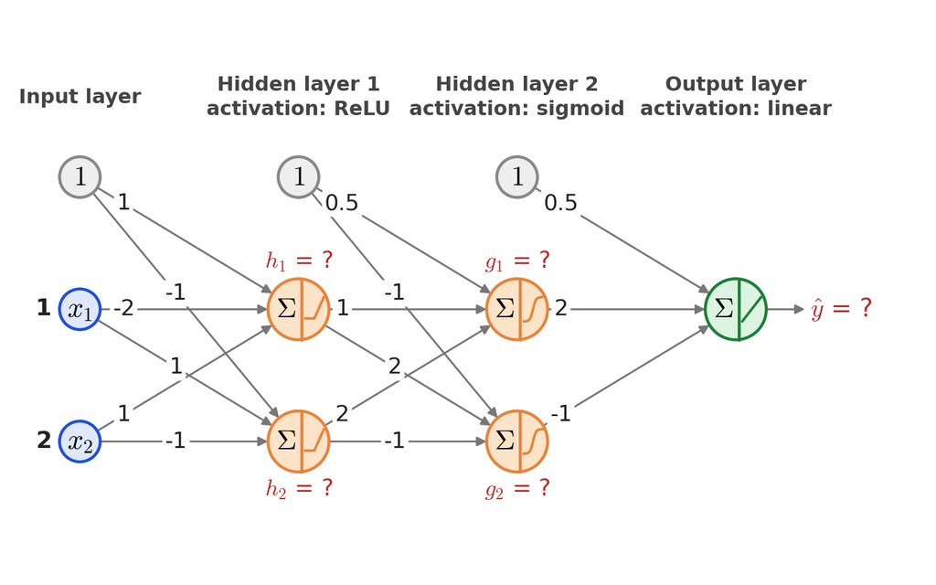

**Regression problem:** the target $y$ is a number, so the output layer is linear and we use the squared loss.

$$l(\hat{y}, y) = (\hat{y} - y)^2$$

One observation has $x_1 = 1$, $x_2 = 2$ and $y = 2$. The weights are on the arrows.

**Activations:** ReLU gives $\max(0, z)$, sigmoid gives $1 / (1 + e^{-z})$, and linear gives $z$.

1. For every node, calculate the value going into the activation and the value coming out of it, ending with $\hat{y}$. Round each step to 3 decimals.
2. Calculate the loss for this observation.
3. How many parameters does this network have?

## Problem: Solution

Blue: the sum going **into** the activation. Red: the value coming **out** of it.

**Hidden layer 1: ReLU**
$$\begin{gathered}\textcolor{#1f4fd8}{z_{h_1} = 1 + (-2)(1) + (1)(2) = 1} \\ \textcolor{#1f4fd8}{z_{h_2} = -1 + (1)(1) + (-1)(2) = -2}\end{gathered}$$
$$\begin{gathered}\textcolor{#b5302a}{h_1 = \max(0,\, 1) = 1} \\ \textcolor{#b5302a}{h_2 = \max(0,\, -2) = 0}\end{gathered}$$

**Hidden layer 2: sigmoid**
$$\begin{gathered}\textcolor{#1f4fd8}{z_{g_1} = 0.5 + (1)(1) + (2)(0) = 1.5} \\ \textcolor{#1f4fd8}{z_{g_2} = -1 + (2)(1) + (-1)(0) = 1}\end{gathered}$$
$$\begin{gathered}\textcolor{#b5302a}{g_1 = \frac{1}{1 + e^{-1.5}} = 0.818} \\ \textcolor{#b5302a}{g_2 = \frac{1}{1 + e^{-1}} = 0.731}\end{gathered}$$

**Output layer: linear**
$$\begin{gathered}\textcolor{#1f4fd8}{z_{\hat{y}} = 0.5 + (2)(0.818) + (-1)(0.731) = 1.405}\end{gathered}$$
$$\begin{gathered}\textcolor{#b5302a}{\hat{y} = z_{\hat{y}} = 1.405}\end{gathered}$$

**Loss:** $l(\hat{y}, y) = (1.405 - 2)^2 = 0.354$.

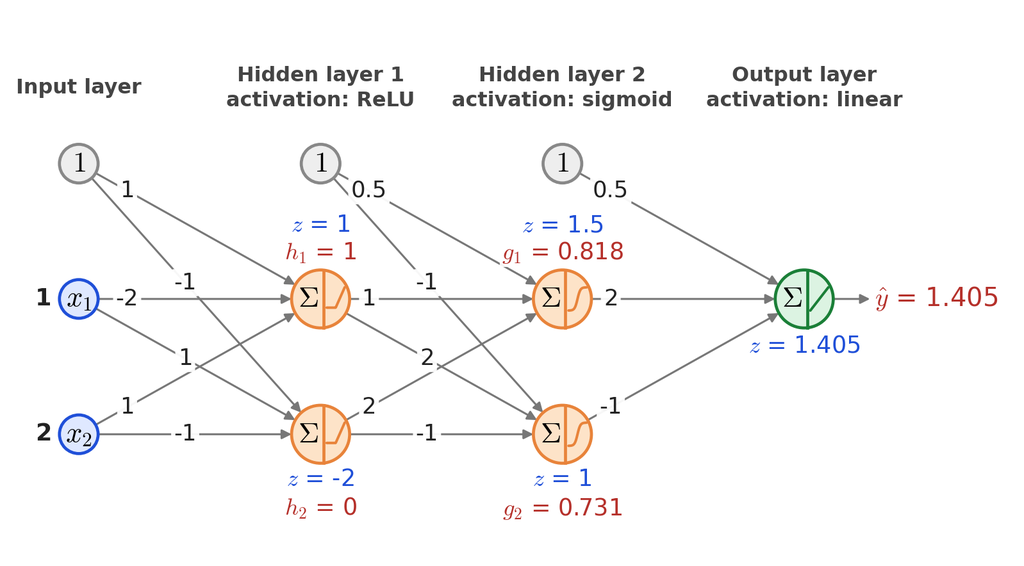

ReLU turns the negative sum $z_{h_2} = -2$ into $h_2 = 0$.

**Parameters:** count the arrows into each layer. The activations add none.

| Arrows into | Arrows per node | Nodes | Parameters |
| --- | --- | --- | --- |
| Hidden layer 1 | 2 inputs + 1 bias = 3 | 2 | $3 \times 2 = 6$ |
| Hidden layer 2 | 2 nodes + 1 bias = 3 | 2 | $3 \times 2 = 6$ |
| Output layer | 2 nodes + 1 bias = 3 | 1 | $3 \times 1 = 3$ |
| **Total** |  |  | $\mathbf{15}$ |